# egzaminas

#### 2 dalis. Tiesinio modelio sudarymas. Naudojame trainSet masyvą.

**(a)** Tiesinis modelis, kuriame prognozuojamas kintamasis yra išlaidos vaisiams.

```r
mod1<-lm(islaidosVaisiams~butinosIslaidos+pajamos+atstumasIkiParduotuves+factor(rajonoId),data=trainSet)
summary(mod1)
```

```
##
## Call:
## lm(formula = islaidosVaisiams ~ butinosIslaidos + pajamos + atstumasIkiParduotuves +
##     factor(rajonoId), data = trainSet)
##
## Residuals:
##      Min       1Q   Median       3Q      Max
## -0.45117 -0.03763  0.00477  0.04613  0.17845
##
## Coefficients:
##                          Estimate Std. Error t value Pr(>|t|)
## (Intercept)            -1.113e-04  2.520e-02  -0.004    0.996
## butinosIslaidos         2.511e-02  1.316e-03  19.082  < 2e-16 ***
## pajamos                 6.978e-03  3.298e-04  21.160  < 2e-16 ***
## atstumasIkiParduotuves  1.958e-05  1.324e-05   1.478    0.140
## factor(rajonoId)2      -4.858e-02  9.381e-03  -5.178 3.96e-07 ***
## factor(rajonoId)3       9.251e-02  9.939e-03   9.307  < 2e-16 ***
## ---
## Signif. codes:  0 '***' 0.001 '**' 0.01 '*' 0.05 '.' 0.1 ' ' 1
##
## Residual standard error: 0.0704 on 320 degrees of freedom
## Multiple R-squared:  0.842,  Adjusted R-squared:  0.8396
## F-statistic: 341.2 on 5 and 320 DF,  p-value: < 2.2e-16
```

Gavome, kad atstumas iki parduotuvės yra nereikšmingas. Sudarysime modelį be jo.

```r
mod2<-lm(islaidosVaisiams~butinosIslaidos+pajamos+factor(rajonoId),data=trainSet)
summary(mod2)
```

```
##
## Call:
## lm(formula = islaidosVaisiams ~ butinosIslaidos + pajamos + factor(rajonoId),
##     data = trainSet)
##
## Residuals:
##      Min       1Q   Median       3Q      Max
## -0.44809 -0.03809  0.00556  0.04572  0.17918
##
## Coefficients:
##                     Estimate Std. Error t value Pr(>|t|)
## (Intercept)        0.0290481  0.0157153   1.848   0.0655 .
## butinosIslaidos    0.0252036  0.0013171  19.136  < 2e-16 ***
## pajamos            0.0069812  0.0003304  21.132  < 2e-16 ***
## factor(rajonoId)2 -0.0476163  0.0093753  -5.079 6.45e-07 ***
## factor(rajonoId)3  0.0932971  0.0099433   9.383  < 2e-16 ***
## ---
## Signif. codes:  0 '***' 0.001 '**' 0.01 '*' 0.05 '.' 0.1 ' ' 1
##
## Residual standard error: 0.07053 on 321 degrees of freedom
## Multiple R-squared:  0.841,  Adjusted R-squared:  0.839
## F-statistic: 424.3 on 4 and 321 DF,  p-value: < 2.2e-16
```

Visi kintamieji yra reikšmingi, išskyrus laisvąjį narį. (p-value < 0.05 => kintamasis reikšmingas)

```r
mod3<-lm(islaidosVaisiams~+butinosIslaidos+pajamos+factor(rajonoId)-1,data=trainSet)
summary(mod3)  # panaikinus laisvąjį narį modelis išsikraipo, todėl aš jį paliksiu.
```

```
##
## Call:
## lm(formula = islaidosVaisiams ~ +butinosIslaidos + pajamos +
##     factor(rajonoId) - 1, data = trainSet)
##
## Residuals:
##      Min       1Q   Median       3Q      Max
## -0.44809 -0.03809  0.00556  0.04572  0.17918
##
## Coefficients:
##                     Estimate Std. Error t value Pr(>|t|)
## butinosIslaidos    0.0252036  0.0013171  19.136  < 2e-16 ***
## pajamos            0.0069812  0.0003304  21.132  < 2e-16 ***
## factor(rajonoId)1  0.0290481  0.0157153   1.848   0.0655 .
## factor(rajonoId)2 -0.0185682  0.0148287  -1.252   0.2114
## factor(rajonoId)3  0.1223452  0.0149787   8.168 7.28e-15 ***
## ---
## Signif. codes:  0 '***' 0.001 '**' 0.01 '*' 0.05 '.' 0.1 ' ' 1
##
## Residual standard error: 0.07053 on 321 degrees of freedom
## Multiple R-squared:  0.9815, Adjusted R-squared:  0.9812
## F-statistic:  3407 on 5 and 321 DF,  p-value: < 2.2e-16
```

```r
# Tolesniai analizei nagrinėsiu mod2 modelį
fit1<-mod2
summary(fit1)
```

```
##
## Call:
## lm(formula = islaidosVaisiams ~ butinosIslaidos + pajamos + factor(rajonoId),
##     data = trainSet)
##
## Residuals:
##      Min       1Q   Median       3Q      Max
## -0.44809 -0.03809  0.00556  0.04572  0.17918
##
## Coefficients:
##                     Estimate Std. Error t value Pr(>|t|)
## (Intercept)        0.0290481  0.0157153   1.848   0.0655 .
## butinosIslaidos    0.0252036  0.0013171  19.136  < 2e-16 ***
## pajamos            0.0069812  0.0003304  21.132  < 2e-16 ***
## factor(rajonoId)2 -0.0476163  0.0093753  -5.079 6.45e-07 ***
## factor(rajonoId)3  0.0932971  0.0099433   9.383  < 2e-16 ***
## ---
## Signif. codes:  0 '***' 0.001 '**' 0.01 '*' 0.05 '.' 0.1 ' ' 1
##
## Residual standard error: 0.07053 on 321 degrees of freedom
## Multiple R-squared:  0.841,  Adjusted R-squared:  0.839
## F-statistic: 424.3 on 4 and 321 DF,  p-value: < 2.2e-16
```

**(c)** Tikrinkite modelio savybes: multikolinerumą, heteroskedastiškumą ir paklaidų normalumą MULTIKOLINEARUMAS:

```r
vif(fit1)
```

```
##                      GVIF Df GVIF^(1/(2*Df))
## butinosIslaidos  1.296592  1        1.138680
## pajamos          1.288665  1        1.135194
## factor(rajonoId) 1.013914  2        1.003461
```

Matome, kad visi yra < 10.  
Jei modelyje yra multikolinearumo problema, galimos regresijos pasekmės:  
1)sulaukiame, kad kintamieji yra nereikšmingi, nors žinome, kad jų bendras poveikis tikrai nėra nulinis; 2)koreliuotų kintamųjų įgyti koeficientai - priešingų reikšmių, t.y. jie vienas kitą kompensuoja. Todėl prarandama aiški interpretacija.  
3)modelio interpretacija tampa neaiški: jei koreliuotą kintamąjį padidiname vientetu, nebegalime tiksliai nusakyti, kaip keičiasi priklausomas kintamasis.

HETEROSKEDASTIŠKUMAS:

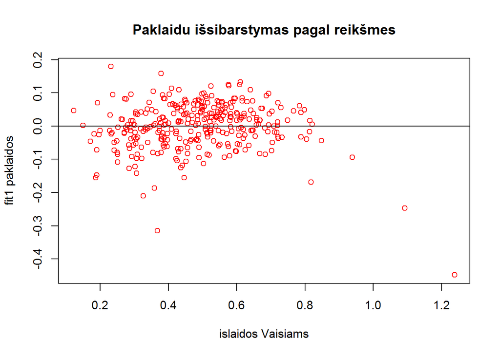

```r
plot(fit1$res~fit1$fitted, main="Paklaidų išsibarstymas pagal reikšmes", col=2, ylab="fit1 paklaidos", xlab="islaidos Vaisiams")
abline(0,0)
```

```r
ncvTest(fit1)
```

```
## Non-constant Variance Score Test
## Variance formula: ~ fitted.values
## Chisquare = 48.81968    Df = 1     p = 2.806104e-12
```

Kadangi p<0.05, vadinasi, atmetame testo H0 hipotezę, kuri teigia, kad modelis yra homoskedastiškas - paklaidų dispersija nėra konstanta.

Jei homoskedastiškumas nėra tenkinamas, tai formaliai didelės blogybės nėra - įverčiai ir toliau liktų nepaslinkti ir suderinti. Visgi reiktų būti atidiem ir papildomai pasvarstyti tris svarbius niuansus:  
1) Nehomogeniškumas gali indikuoti modelio neadekvatumą. Pvz. gal liko nepastebėta netiesinė sąveiką? O gal liko didelių išskirčių?  
2) Statistinio reikšmingumo tikrinimui naudojama kovariacijų matrica gali būti neteisinga. 3) Nors įverčiai nepaslinkti, bet dabar negalime teigti, kad jie yra efektyvūs - tokiu atveju gali būti ir geresnių vertinimo būdų.

PAKLAIDŲ NORMALUMAS:

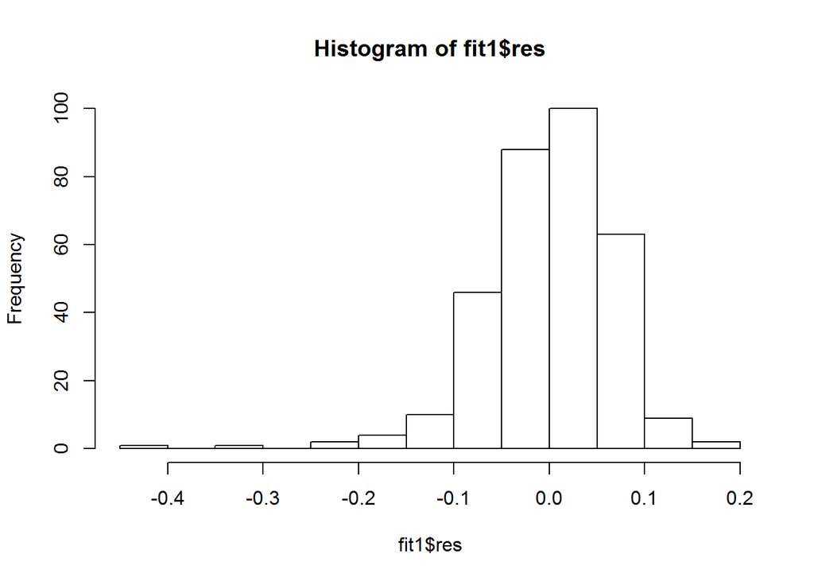

```r
hist(fit1$res)   # nemanau, kad paklaidos bus normalios, nes yra poslinkis.
```

```r
shapiro.test(fit1$res)
```

```
##
##  Shapiro-Wilk normality test
##
## data:  fit1$res
## W = 0.9316, p-value = 4.309e-11
```

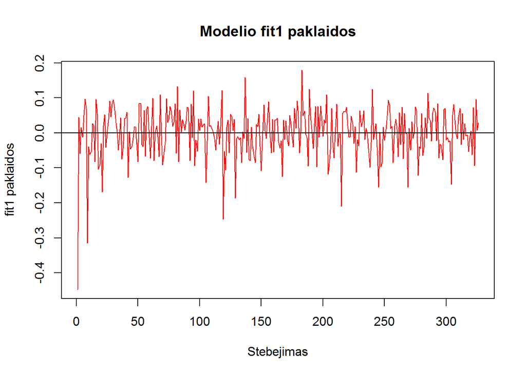

```r
plot(residuals(mod2), type="l", main="Modelio fit1 paklaidos", ylab="fit1 paklaidos", xlab="Stebėjimas", col=2)
abline(0,0)
```

p-value < 0.05 => H0 atmetame, tai patvirtina, kad liekanų paklaidos nėra normalios. Tą mes ir spėjome.

LIEKANŲ AUTOKORELIACIJA:

```r
durbinWatsonTest(fit1)
```

```
##  lag Autocorrelation D-W Statistic p-value
##    1     -0.04384177      1.961426   0.696
##  Alternative hypothesis: rho != 0
```

Kadangi testo p-value > 0.05 => H0: nėra koreliacijos tarp liekanų, priimame.

#### 3 dalis. Modelio tobulinimas.

**(a)**Pateikite dvi sklaidos diagramas. Pirmoji tarp modelio paklaidų ir butinosIslaidos kintamojo. O antroji, tarp modelio paklaidų ir pajamos kintamojo. Pakomentuokite rezultatus. Tendencijų išryškinimui gali būti naudinga lowess funkcija.

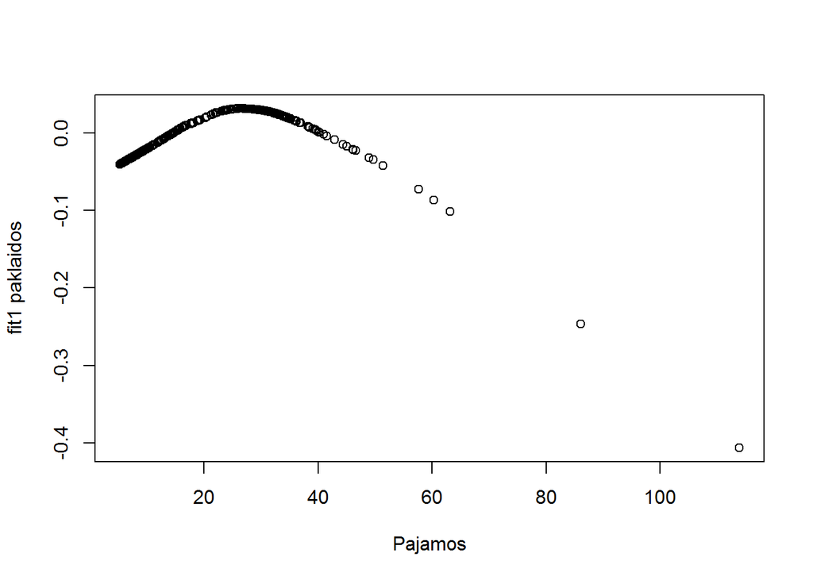

```r
plot(lowess(fit1$res~trainSet$pajamos), ylab="fit1 paklaidos", xlab="Pajamos") # matoma parabolė
```

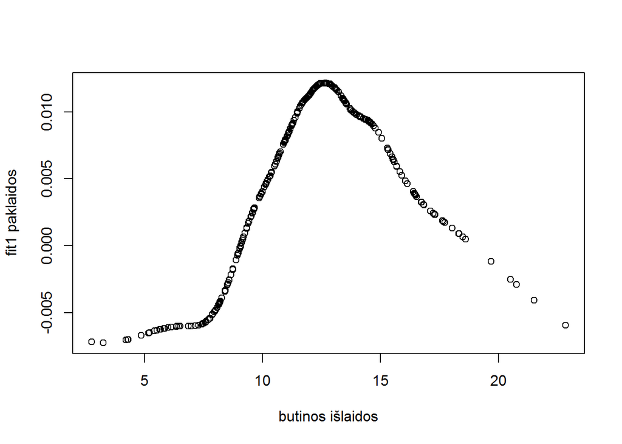

```r
plot(lowess(mod2$res~trainSet$butinosIslaidos), ylab="fit1 paklaidos", xlab="butinos išlaidos")   #irgi kažkas panašaus į parabolę.
```

Matome, kad priklausomumas tikrai nėra tiesiškas, gali būti kad tikslingiau bus imti kvadratus.

**(b)** Bandom dar kažką pakeisti:

```r
mo1<-lm(islaidosVaisiams~butinosIslaidos+I(pajamos^2)+factor(rajonoId),data=trainSet)
summary(mo1)  # kinatmieji liko reikšmongi
```

```
##
## Call:
## lm(formula = islaidosVaisiams ~ butinosIslaidos + I(pajamos^2) +
##     factor(rajonoId), data = trainSet)
##
## Residuals:
##      Min       1Q   Median       3Q      Max
## -0.54065 -0.06534  0.01771  0.07486  0.19544
##
## Coefficients:
##                     Estimate Std. Error t value Pr(>|t|)
## (Intercept)        5.613e-02  2.141e-02   2.622  0.00917 **
## butinosIslaidos    3.235e-02  1.679e-03  19.262  < 2e-16 ***
## I(pajamos^2)       5.730e-05  5.741e-06   9.981  < 2e-16 ***
## factor(rajonoId)2 -3.993e-02  1.267e-02  -3.151  0.00178 **
## factor(rajonoId)3  9.509e-02  1.345e-02   7.071 9.68e-12 ***
## ---
## Signif. codes:  0 '***' 0.001 '**' 0.01 '*' 0.05 '.' 0.1 ' ' 1
##
## Residual standard error: 0.09528 on 321 degrees of freedom
## Multiple R-squared:  0.7098, Adjusted R-squared:  0.7062
## F-statistic: 196.3 on 4 and 321 DF,  p-value: < 2.2e-16
```

```r
mo2<-lm(islaidosVaisiams~I(butinosIslaidos^2)+I(pajamos^2)+factor(rajonoId),data=trainSet)
summary(mo2)  # visi kintamieji reikšmingi + laisvasis narys reikšmingas
```

```
##
## Call:
## lm(formula = islaidosVaisiams ~ I(butinosIslaidos^2) + I(pajamos^2) +
##     factor(rajonoId), data = trainSet)
##
## Residuals:
##      Min       1Q   Median       3Q      Max
## -0.55700 -0.07292  0.01447  0.07860  0.20121
##
## Coefficients:
##                        Estimate Std. Error t value Pr(>|t|)
## (Intercept)           2.451e-01  1.447e-02  16.942  < 2e-16 ***
## I(butinosIslaidos^2)  1.273e-03  7.208e-05  17.657  < 2e-16 ***
## I(pajamos^2)          5.846e-05  6.013e-06   9.723  < 2e-16 ***
## factor(rajonoId)2    -4.081e-02  1.325e-02  -3.080  0.00225 **
## factor(rajonoId)3     9.572e-02  1.407e-02   6.802 5.04e-11 ***
## ---
## Signif. codes:  0 '***' 0.001 '**' 0.01 '*' 0.05 '.' 0.1 ' ' 1
##
## Residual standard error: 0.09964 on 321 degrees of freedom
## Multiple R-squared:  0.6826, Adjusted R-squared:  0.6787
## F-statistic: 172.6 on 4 and 321 DF,  p-value: < 2.2e-16
```

```r
mo3<-lm(islaidosVaisiams~I(butinosIslaidos^2)+pajamos+factor(rajonoId),data=trainSet)
summary(mo3)  # visi kintamieji reikšmingi + laisvasis narys reikšmingas
```

```
##
## Call:
## lm(formula = islaidosVaisiams ~ I(butinosIslaidos^2) + pajamos +
##     factor(rajonoId), data = trainSet)
##
## Residuals:
##      Min       1Q   Median       3Q      Max
## -0.46793 -0.03895  0.00374  0.05071  0.16127
##
## Coefficients:
##                        Estimate Std. Error t value Pr(>|t|)
## (Intercept)           1.733e-01  1.129e-02  15.359  < 2e-16 ***
## I(butinosIslaidos^2)  9.854e-04  5.593e-05  17.618  < 2e-16 ***
## pajamos               7.188e-03  3.423e-04  21.000  < 2e-16 ***
## factor(rajonoId)2    -4.838e-02  9.780e-03  -4.947 1.22e-06 ***
## factor(rajonoId)3     9.395e-02  1.038e-02   9.052  < 2e-16 ***
## ---
## Signif. codes:  0 '***' 0.001 '**' 0.01 '*' 0.05 '.' 0.1 ' ' 1
##
## Residual standard error: 0.07358 on 321 degrees of freedom
## Multiple R-squared:  0.8269, Adjusted R-squared:  0.8248
## F-statistic: 383.4 on 4 and 321 DF,  p-value: < 2.2e-16
```

```r
# Galbūt sudarėme kelis visai neblogus modelius. Pažiūrėsime kuris yra tinkamiausias atsižvelgiant į AIC
AIC(mo1);AIC(mo2);AIC(mo3)
```

```
## [1] -600.7185
```

```
## [1] -571.5457
```

```
## [1] -769.2117
```

```r
# Mažiausią AIC turi mo3, taigi jį pasirenkame kaip antrąjį tinkamą modelį
fit2<-mo3
```

**(c)**

```r
# modeliui fit1
mse1<-(1/(326)*sum(fit1$res)^2)  # trainSet
mse1
```

```
## [1] 2.286927e-32
```

```r
mse2<-(1/(89)*sum(fit1$res)^2)   # testSet
mse2
```

```
## [1] 8.376835e-32
```

```r
# modeliui fit2
mse11<-(1/(326)*sum(fit2$res)^2) # trainSet
mse11
```

```
## [1] 2.888674e-32
```

```r
mse22<-(1/(89)*sum(fit2$res)^2)  # testSet
mse22
```

```
## [1] 1.058099e-31
```

```r
a<-rbind(mse1,mse2,mse11,mse22)
a
```

```
##               [,1]
## mse1  2.286927e-32
## mse2  8.376835e-32
## mse11 2.888674e-32
## mse22 1.058099e-31
```

```r
colnames(a)<-c("MSE")
a
```

```
##                MSE
## mse1  2.286927e-32
## mse2  8.376835e-32
## mse11 2.888674e-32
## mse22 1.058099e-31
```

```r
fitMain<-fit1 # pasirenkame pirmą modelį
summary(fit1)
```

```
##
## Call:
## lm(formula = islaidosVaisiams ~ butinosIslaidos + pajamos + factor(rajonoId),
##     data = trainSet)
##
## Residuals:
##      Min       1Q   Median       3Q      Max
## -0.44809 -0.03809  0.00556  0.04572  0.17918
##
## Coefficients:
##                     Estimate Std. Error t value Pr(>|t|)
## (Intercept)        0.0290481  0.0157153   1.848   0.0655 .
## butinosIslaidos    0.0252036  0.0013171  19.136  < 2e-16 ***
## pajamos            0.0069812  0.0003304  21.132  < 2e-16 ***
## factor(rajonoId)2 -0.0476163  0.0093753  -5.079 6.45e-07 ***
## factor(rajonoId)3  0.0932971  0.0099433   9.383  < 2e-16 ***
## ---
## Signif. codes:  0 '***' 0.001 '**' 0.01 '*' 0.05 '.' 0.1 ' ' 1
##
## Residual standard error: 0.07053 on 321 degrees of freedom
## Multiple R-squared:  0.841,  Adjusted R-squared:  0.839
## F-statistic: 424.3 on 4 and 321 DF,  p-value: < 2.2e-16
```

### 3 Užduotis

#### 1 dalis. Duomenų paruošimas.

**(a)** Susidarome modelį:

```r
head(M1Germany)
```

```
##            logm1 logprice   loggnp interest
## 1960 Q1 7.947090 3.403827 8.309448    0.062
## 1960 Q2 7.996191 3.380212 8.387236    0.064
## 1960 Q3 7.949908 3.436211 8.465361    0.064
## 1960 Q4 8.030746 3.419888 8.477333    0.062
## 1961 Q1 7.951792 3.449861 8.374404    0.060
## 1961 Q2 8.020040 3.427157 8.420854    0.057
```

```r
modd<-dynlm(logprice~L(loggnp, 1)+I(L(loggnp,2)-L(loggnp,3)), data=M1Germany)
# I(L(loggnp,2)-L(loggnp,3)), tai yra loggnp su 2 lagais - loggnp su 3 lagais, nes turim delta, skirtumo operatorių.
summary(modd)
```

```
##
## Time series regression with "zooreg" data:
## Start = 1960 Q4, End = 1996 Q1
##
## Call:
## dynlm(formula = logprice ~ L(loggnp, 1) + I(L(loggnp, 2) - L(loggnp,
##     3)), data = M1Germany)
##
## Residuals:
##      Min       1Q   Median       3Q      Max
## -0.18535 -0.06962 -0.01279  0.06643  0.26184
##
## Coefficients:
##                                 Estimate Std. Error t value Pr(>|t|)
## (Intercept)                    -11.06151    0.34114  -32.42   <2e-16 ***
## L(loggnp, 1)                     1.71053    0.03837   44.58   <2e-16 ***
## I(L(loggnp, 2) - L(loggnp, 3))  -0.26488    0.15577   -1.70   0.0913 .
## ---
## Signif. codes:  0 '***' 0.001 '**' 0.01 '*' 0.05 '.' 0.1 ' ' 1
##
## Residual standard error: 0.1055 on 139 degrees of freedom
## Multiple R-squared:  0.9349, Adjusted R-squared:  0.9339
## F-statistic: 997.7 on 2 and 139 DF,  p-value: < 2.2e-16
```

**(b)** Gaukite įvertintos lygties liekanas. Jas vadinsime serOrg. Rekomenduojama liekanų objektą transformuoti į laiko eilučių klasę (ts).

```r
modd$res
```

```
##       1960 Q4       1961 Q1       1961 Q2       1961 Q3       1961 Q4
##  0.0217142214  0.0312967089  0.1671346877  0.1089560957  0.0383877397
##       1962 Q1       1962 Q2       1962 Q3       1962 Q4       1963 Q1
##  0.0525794747  0.1862995137  0.0755993030  0.0037189597  0.0349015801
##       1963 Q2       1963 Q3       1963 Q4       1964 Q1       1964 Q2
##  0.2600118371  0.0516250834 -0.0136332675 -0.0049134788  0.1409862107
##       1964 Q3       1964 Q4       1965 Q1       1965 Q2       1965 Q3
## -0.0122828797 -0.0379151039 -0.0350138739  0.0967394786 -0.0421755531
##       1965 Q4       1966 Q1       1966 Q2       1966 Q3       1966 Q4
## -0.0645367156 -0.0684250270  0.0675699580 -0.0603644462 -0.0603861442
##       1967 Q1       1967 Q2       1967 Q3       1967 Q4       1968 Q1
## -0.0487001335  0.1153650139 -0.0253774174 -0.0305094066 -0.0749001396
##       1968 Q2       1968 Q3       1968 Q4       1969 Q1       1969 Q2
##  0.0975553352 -0.0571595670 -0.1184996736 -0.1469597066  0.0252916857
##       1969 Q3       1969 Q4       1970 Q1       1970 Q2       1970 Q3
## -0.1314923066 -0.1680269663 -0.1853505886  0.0227224633 -0.1627912557
##       1970 Q4       1971 Q1       1971 Q2       1971 Q3       1971 Q4
## -0.1512603371 -0.1782565781  0.0058901831 -0.1091040334 -0.1109437011
##       1972 Q1       1972 Q2       1972 Q3       1972 Q4       1973 Q1
## -0.1316262757 -0.0112981412 -0.1036278859 -0.1069321403 -0.1570404312
##       1973 Q2       1973 Q3       1973 Q4       1974 Q1       1974 Q2
## -0.0456206677 -0.1182305503 -0.1074441944 -0.1506772979 -0.0016139577
##       1974 Q3       1974 Q4       1975 Q1       1975 Q2       1975 Q3
## -0.0547537310 -0.0267131375 -0.0598814472  0.1076209417  0.0152390205
##       1975 Q4       1976 Q1       1976 Q2       1976 Q3       1976 Q4
##  0.0333349996 -0.0586760164  0.0457456074 -0.0429832923 -0.0129763771
##       1977 Q1       1977 Q2       1977 Q3       1977 Q4       1978 Q1
## -0.1274100327  0.0159018809 -0.0552737256 -0.0086982448 -0.1367185692
##       1978 Q2       1978 Q3       1978 Q4       1979 Q1       1979 Q2
##  0.0095621828 -0.0730189550 -0.0390406978 -0.1512980205 -0.0233531128
##       1979 Q3       1979 Q4       1980 Q1       1980 Q2       1980 Q3
## -0.1157454163 -0.0616377783 -0.1659651067 -0.0355025645 -0.0706084496
##       1980 Q4       1981 Q1       1981 Q2       1981 Q3       1981 Q4
## -0.0265130695 -0.1082859816  0.0184083687 -0.0238747841  0.0150875947
##       1982 Q1       1982 Q2       1982 Q3       1982 Q4       1983 Q1
## -0.0700168208  0.0738138892  0.0213609926  0.0821184953 -0.0126021340
##       1983 Q2       1983 Q3       1983 Q4       1984 Q1       1984 Q2
##  0.0894776371  0.0231248315  0.0718680555 -0.0554190543  0.0382414772
##       1984 Q3       1984 Q4       1985 Q1       1985 Q2       1985 Q3
##  0.0085903022  0.0169934452 -0.0914659866  0.0503546842 -0.0319410370
##       1985 Q4       1986 Q1       1986 Q2       1986 Q3       1986 Q4
## -0.0058413587 -0.0900178662  0.0630198508 -0.0535048148 -0.0108375052
##       1987 Q1       1987 Q2       1987 Q3       1987 Q4       1988 Q1
## -0.1099371254  0.0577974128 -0.0532936033 -0.0221439196 -0.1264299068
##       1988 Q2       1988 Q3       1988 Q4       1989 Q1       1989 Q2
## -0.0001098304 -0.0765158048 -0.0499755828 -0.1327535781 -0.0374532824
##       1989 Q3       1989 Q4       1990 Q1       1990 Q2       1990 Q3
## -0.1005624622 -0.0432105977 -0.1341038082 -0.0588900177 -0.1069172093
##       1990 Q4       1991 Q1       1991 Q2       1991 Q3       1991 Q4
##  0.1234215194  0.0230485457  0.1330690353  0.0887698747  0.1300031134
##       1992 Q1       1992 Q2       1992 Q3       1992 Q4       1993 Q1
##  0.0832156896  0.1491385048  0.1356126674  0.1595221410  0.1134215765
##       1993 Q2       1993 Q3       1993 Q4       1994 Q1       1994 Q2
##  0.2618449782  0.1869926315  0.2166266775  0.1730035895  0.2426154100
##       1994 Q3       1994 Q4       1995 Q1       1995 Q2       1995 Q3
##  0.1778722933  0.2050194473  0.1567764197  0.2289315685  0.1698542352
##       1995 Q4       1996 Q1
##  0.1990496452  0.1661448930
```

```r
str(modd$res)
```

```
## 'zooreg' series from 1960 Q4 to 1996 Q1
##   Data: num [1:142] 0.0217 0.0313 0.1671 0.109 0.0384 ...
##   Index: Class 'yearqtr'  num [1:142] 1961 1961 1961 1962 1962 ...
##   Frequency: 4
```

```r
ser<-ts(modd$res, start =c(1960,4), frequency=4 )
```

**(c)** Ar `ser` stacionari eilutė? H0: duomenys stacionarūs; H1: nestacionarūs.

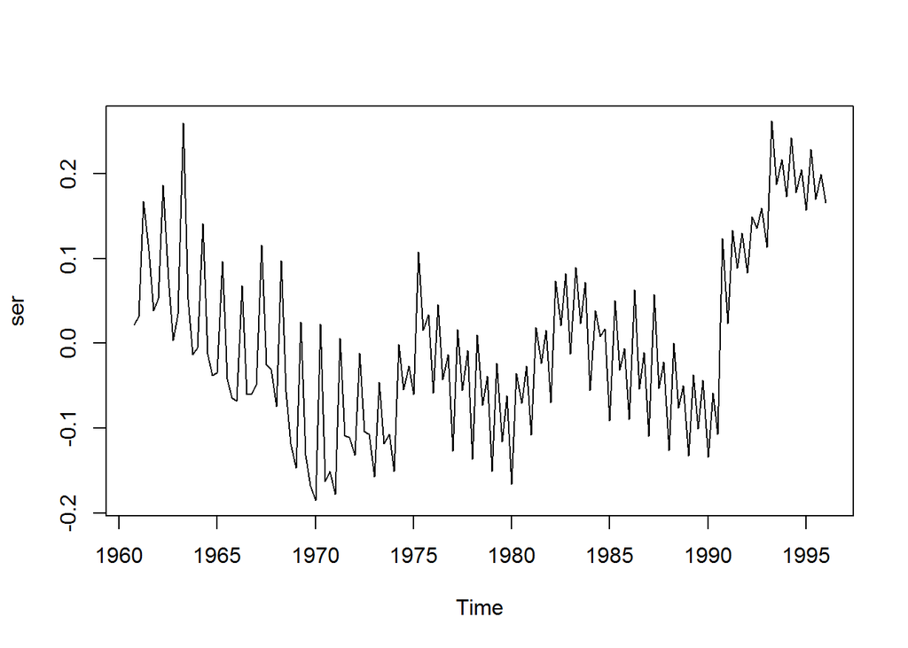

```r
plot(ser)
```

```r
kpss.test(ser) # p-value < 0.05 => H0 atmetame. Turimi duomenys nėra stacionarūs. Bamdysim diferencijuoti.
```

```
##
##  KPSS Test for Level Stationarity
##
## data:  ser
## KPSS Level = 1.0861, Truncation lag parameter = 2, p-value = 0.01
```

```r
ns<-ndiffs(ser) ## surandame diferencijavimo eile
ns
```

```
## [1] 1
```

```r
kpss.test(diff(ser,differences=ns)) # p-vaule > 0.05 H0 priimame. Duomenys yra stacionarūs.
```

```
##
##  KPSS Test for Level Stationarity
##
## data:  diff(ser, differences = ns)
## KPSS Level = 0.0385, Truncation lag parameter = 2, p-value = 0.1
```

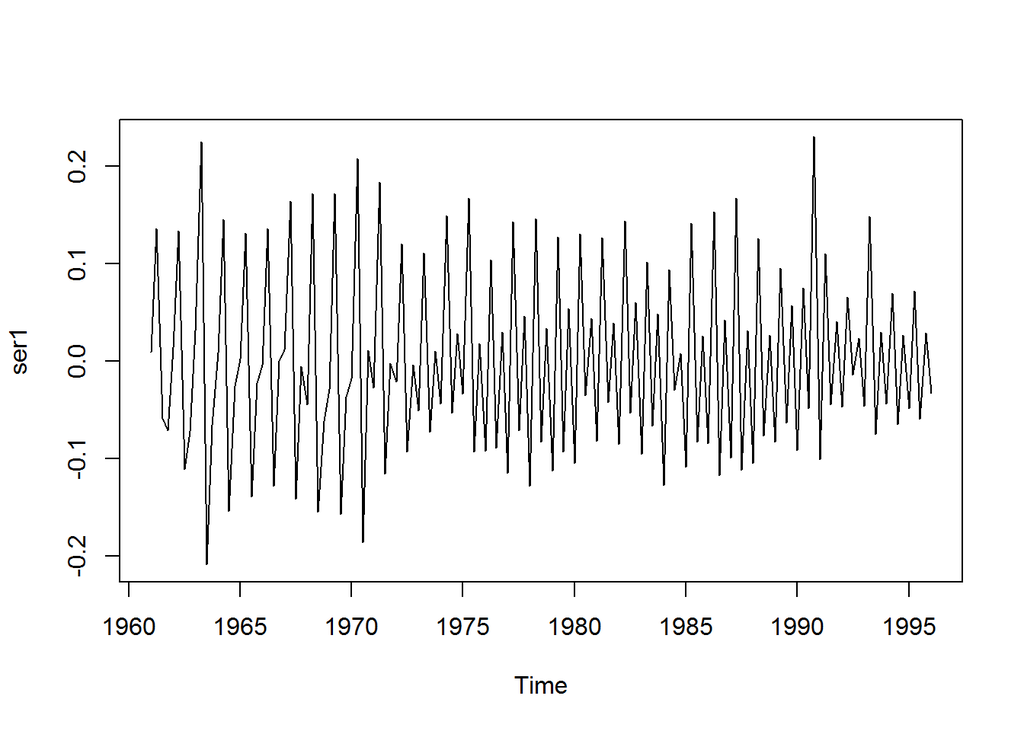

```r
ser1<-diff(ser,differences=ns)
plot(ser1)  # stacionari eilutė
```

**(d)**

```r
l<- BoxCox.lambda(ser);l
```

```
## [1] 1.314823
```

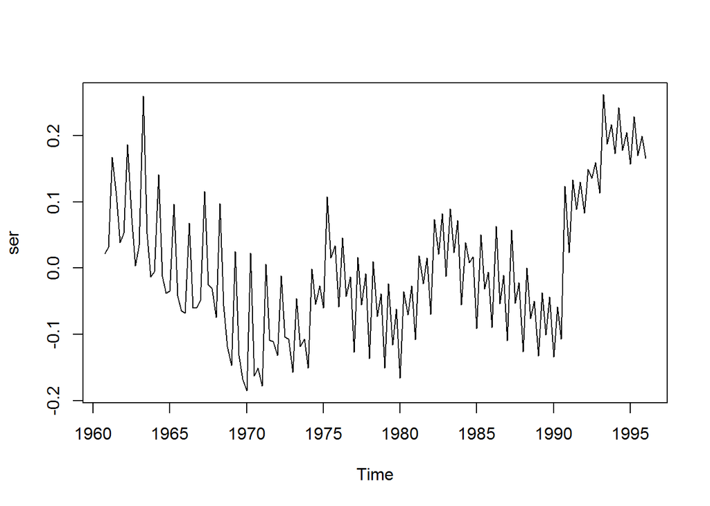

```r
plot(ser)
```

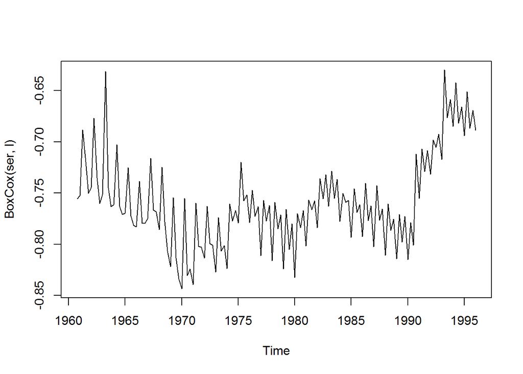

```r
plot(BoxCox(ser, l))
```

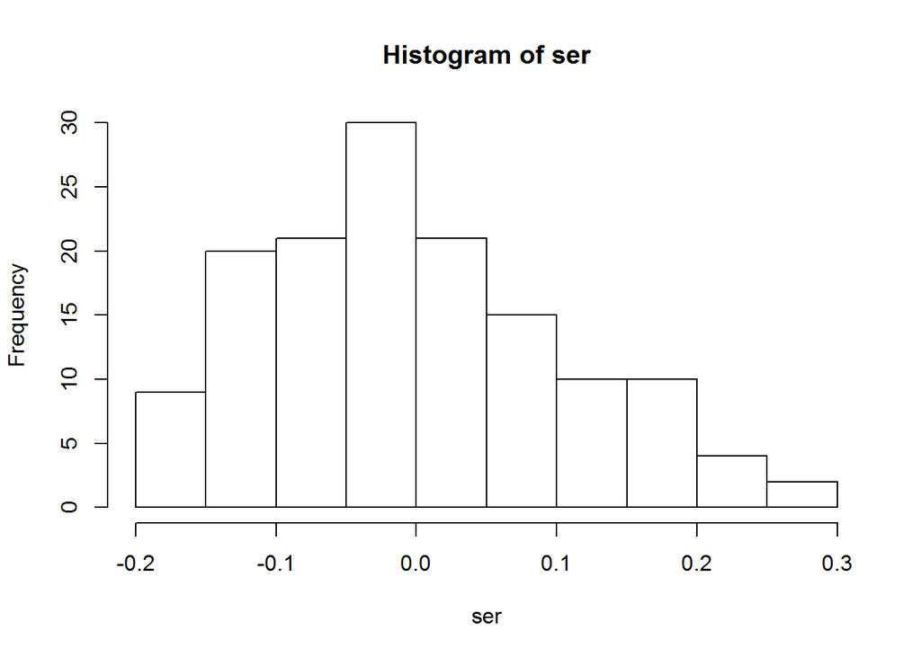

```r
hist(ser)
```

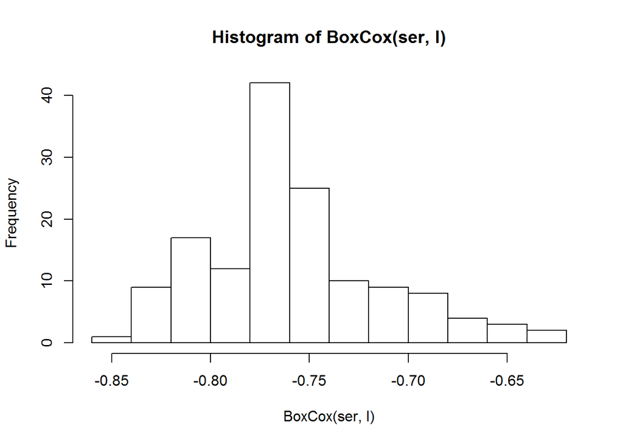

```r
hist(BoxCox(ser, l))
```

```r
ser2<-BoxCox(ser, l)
```

Box-Cox transformacija manau yra naudinga, duoda pokyčius, histograma labiau tampa panaši į varpą.

#### 2 dalis MODELIAVIMAS

**(a)** auto ets

```r
mod1<-ets(ser, lambda=l)  # darome su tranformuotais duomenimis
summary(mod1)
```

```
## ETS(A,N,A)
##
## Call:
##  ets(y = ser, lambda = l)
##
##   Box-Cox transformation: lambda= 1.3148
##
##   Smoothing parameters:
##     alpha = 0.5733
##     gamma = 0.2922
##
##   Initial states:
##     l = -0.7309
##     s=-0.0032 0.0494 -0.0213 -0.0249
##
##   sigma:  0.0148
##
##       AIC      AICc       BIC
## -480.3909 -479.7687 -462.6560
##
## Training set error measures:
##                       ME       RMSE        MAE      MPE     MAPE      MASE
## Training set 0.001231671 0.03470289 0.02452491 148.8769 213.1016 0.6664445
##                   ACF1
## Training set 0.1335944
```

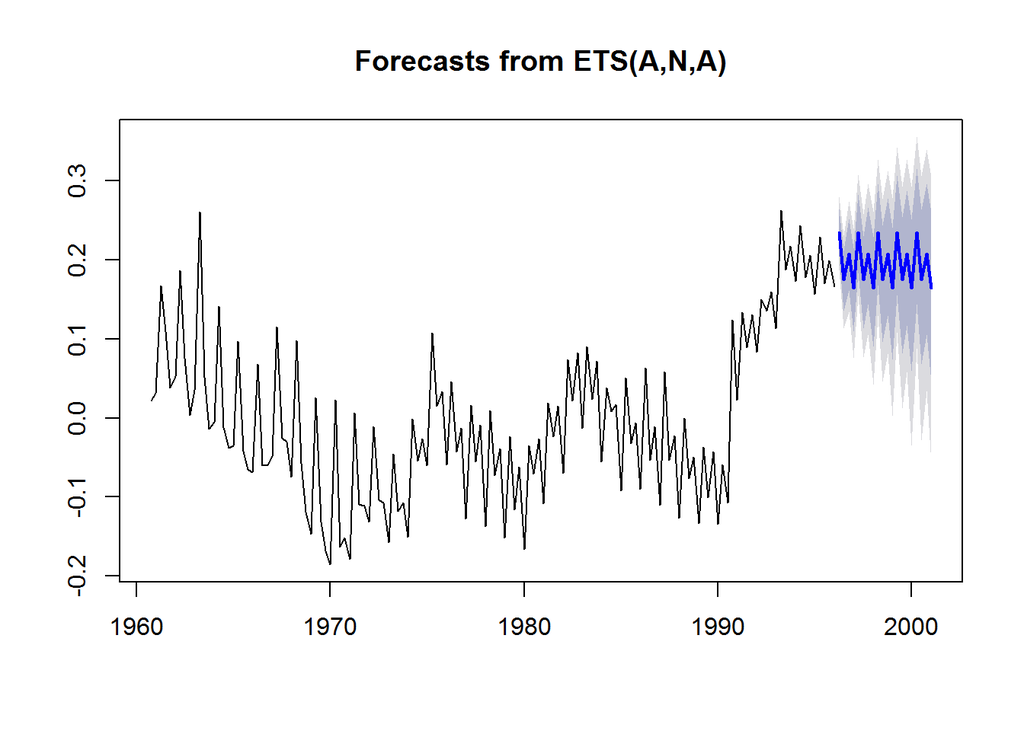

```r
forc1 <- forecast(mod1, h=20)
plot(forc1)
```

Gavome ETS(A,N,A), A- additive errors, N- no trend, A - Seasonal Component

**(b)** Kiti variantai:

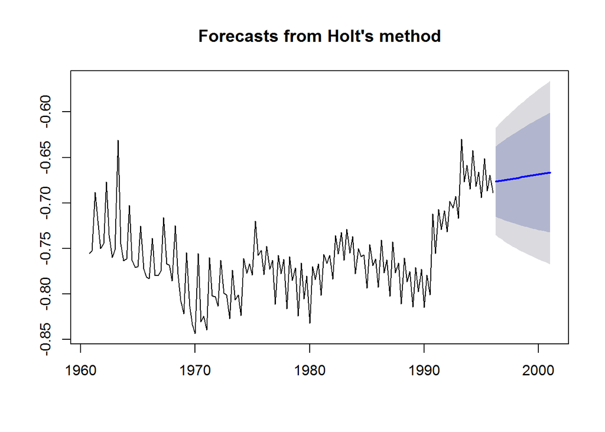

```r
pirm<-holt(ser2, h=20)  # čia panaudosiu ser2, nes rašant lambda=l išmeta nesąmonę, kurios nemoku pataisyt
plot(pirm)
```

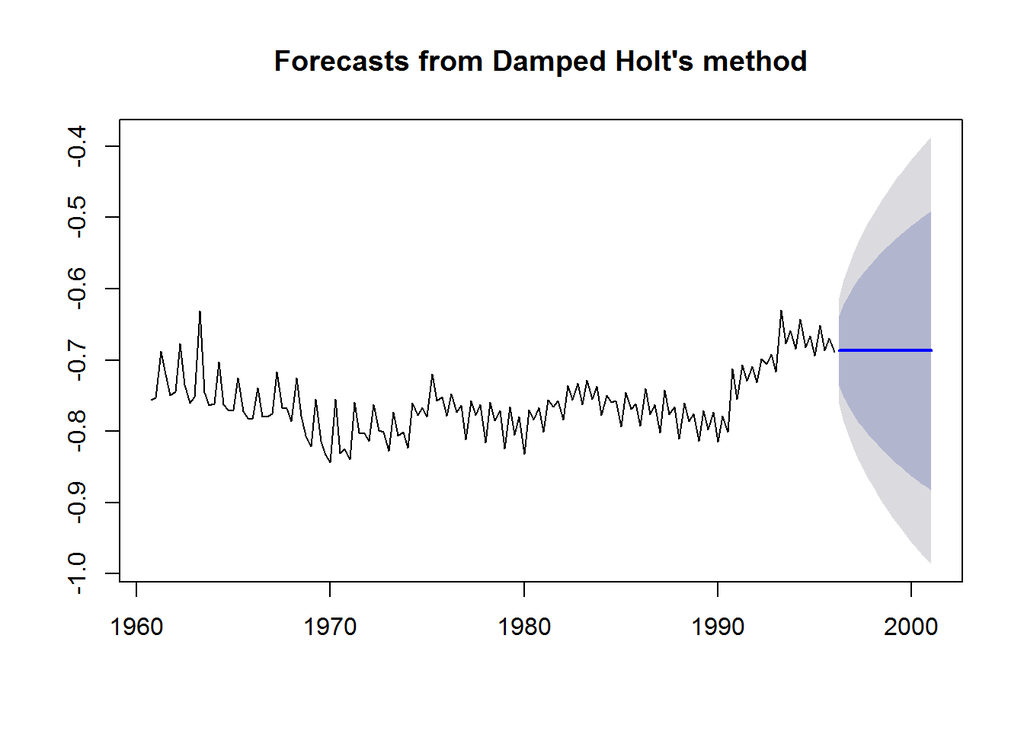

```r
antr<-holt(ser2, h=20,damped=TRUE, alpha=0.9) # čia panaudosiu ser2, nes rašant lambda=l išmeta nesąmonę, kurios nemoku pataisyt
plot(antr)
```

```r
# pasirinksime geriausią modelį
accuracy(pirm);accuracy(antr)
```

```
##                         ME       RMSE        MAE        MPE     MAPE
## Training set -0.0001352026 0.03006574 0.02419765 -0.1322213 3.225771
##                  MASE       ACF1
## Training set 1.580997 -0.2275806
```

```
##                        ME       RMSE        MAE        MPE     MAPE
## Training set 0.0003961158 0.03782555 0.03076338 -0.1979247 4.112628
##                  MASE       ACF1
## Training set 2.009982 -0.5622297
```

```r
# Mažiausią RMSE turi pirm modelis, todėl jį pasirenkame kaip mod2
mod2<-pirm
```

`mod2` nuo `mod1` skiriasi tuo, kad mod2 nevertina sezoniškumo, jo prognozė nešokinėja, yra tiesė.

**(c)** `auto.arima` funkcija:

```r
mod3<-auto.arima(ser,lambda=l)
summary(mod3)
```

```
## Series: ser
## ARIMA(1,1,0)(2,0,1)[4]
## Box Cox transformation: lambda= 1.314823
##
## Coefficients:
##           ar1    sar1     sar2     sma1
##       -0.3262  1.1915  -0.2260  -0.7415
## s.e.   0.0871  0.0978   0.0934   0.0642
##
## sigma^2 estimated as 0.0002205:  log likelihood=393.52
## AIC=-769.68   AICc=-769.23   BIC=-754.93
##
## Training set error measures:
##                       ME       RMSE        MAE       MPE     MAPE
## Training set 0.002574555 0.03345421 0.02284209 -4.715752 81.01385
##                   MASE       ACF1
## Training set 0.6207153 0.03961438
```

ARIMA(1,1,0)(2,0,1)[4], tai yra ARIMA(p,d,q)(P,D,Q) Mažosios raides žymi nesezoninę modelio dalį: p - autoregresine modelio dalis d - diferencijavimo eile q - moving average modelio dalis Didžiosios raides raides tas pats kas ir mažosios tik jos yra skirtos sezoniniai modelio daliai aprašyti. Indeksas salia antruju skliaustu reiskia periodu skaiciu per sezona. Šiuo atvėju 4, net yra ketvirčiai. Buvo siūloma diferencijuoti vieną kartą, auto.arima duoda d=1, taigi sutampa.

**(d)** Eksperimentuojam:

```r
m1<-arima(ser2, order = c(1,1,0),seasonal = list(order=c(1,0,1),period=4))  # arima() neduoda naudoti lamda=l, todėl naudosiu ser2 duomenis
m2<-arima(ser2, order = c(2,1,0),seasonal = list(order=c(2,0,0),period=4))
m3<-arima(ser2, order = c(2,1,1),seasonal = list(order=c(1,0,1),period=4))

accuracy(m1)
```

```
##                        ME       RMSE        MAE         MPE     MAPE
## Training set 0.0001668418 0.01541429 0.01079837 -0.03732688 1.453214
##                   MASE        ACF1
## Training set 0.3258992 -0.05052208
```

```r
accuracy(m2)
```

```
##                        ME       RMSE        MAE         MPE     MAPE
## Training set 7.291909e-05 0.01592335 0.01108924 -0.02759976 1.498315
##                   MASE        ACF1
## Training set 0.3346779 0.003000706
```

```r
accuracy(m3)
```

```
##                        ME       RMSE        MAE         MPE     MAPE
## Training set 0.0003107087 0.01509412 0.01079053 -0.05717072 1.449952
##                   MASE         ACF1
## Training set 0.3256626 -0.002140656
```

```r
# mažiausias RMSE yra m3, todėl jį pasirenkame kaip geriausią.
mod4<-m3
```

#### 3 dalis. Modelių tyrimas ir palyginimas

**(a)** Ar modelių liekanos yra baltas triukšmas? Naudosim Ljung–Box testą: H0: liekanos yra baltasis triukšmas; H1: liekanos nėra baltasis triukšmas.

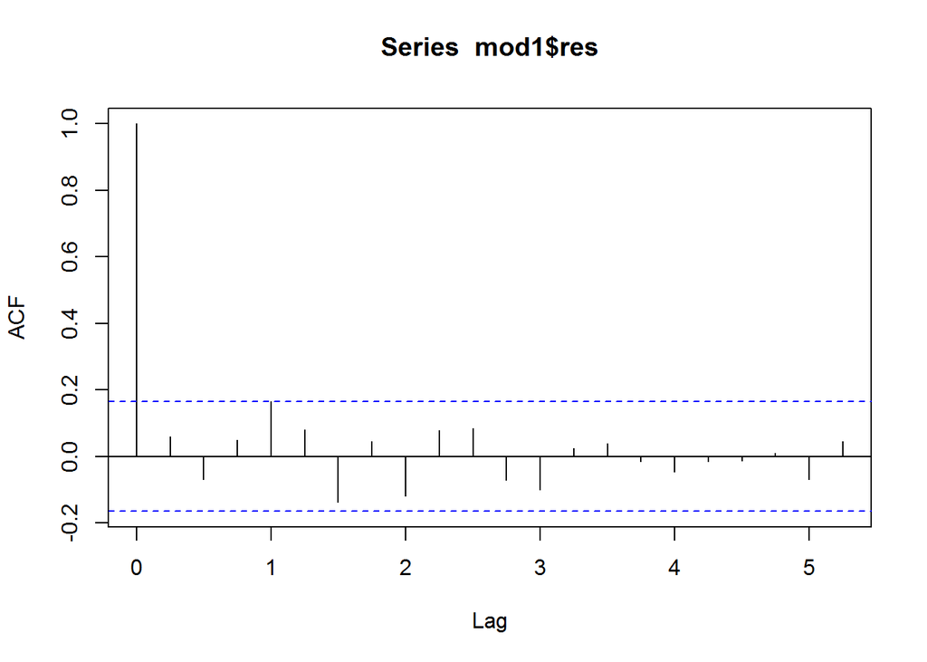

```r
acf(mod1$res)  # Tikėtina, kad bus baltasis triukšmas.
```

```r
Box.test(mod1$res, fitdf=0, type="Lj")
```

```
##
##  Box-Ljung test
##
## data:  mod1$res
## X-squared = 0.5198, df = 1, p-value = 0.4709
```

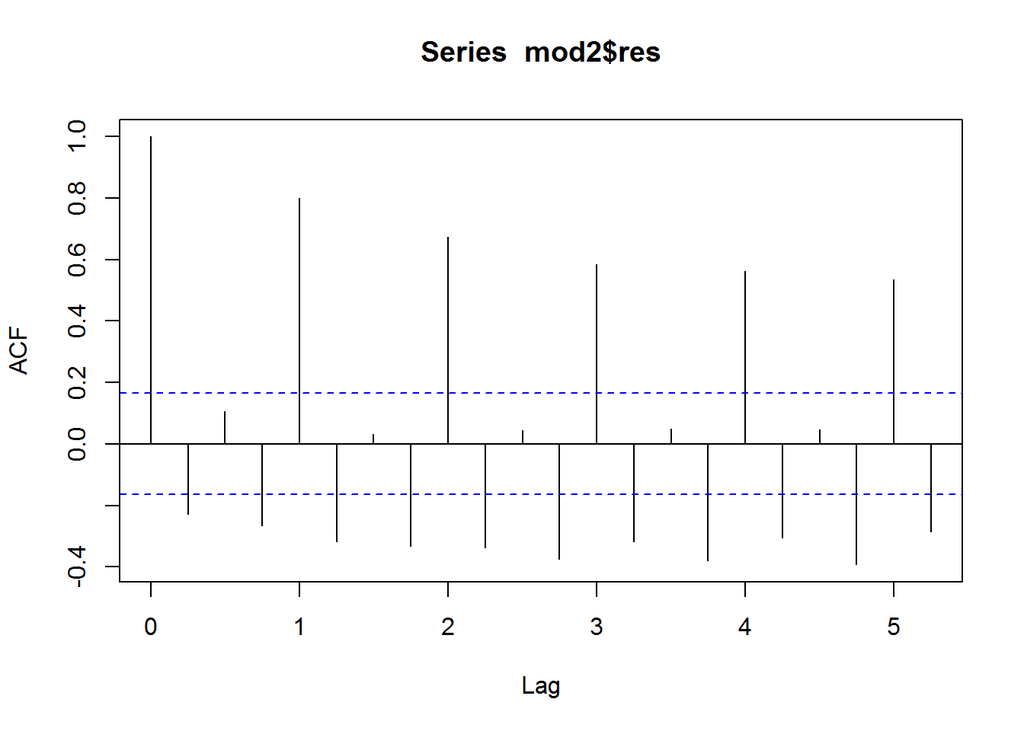

```r
#p-value > 0.05 => H0 priimame. mod1 liekanos yra baltasis triukšmas.

acf(mod2$res)  # Tikrai nebus baltasis triukšmas.
```

```r
Box.test(mod2$res, fitdf=0, type="Lj")
```

```
##
##  Box-Ljung test
##
## data:  mod2$res
## X-squared = 7.5111, df = 1, p-value = 0.006132
```

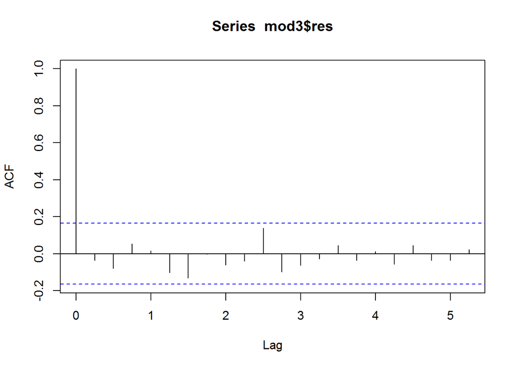

```r
#p-value < 0.05 => H0 atmetame. mod2 liekanos nėra baltasis triukšmas.

acf(mod3$res)  # Tikėtina, kad bus baltasis triukšmas.
```

```r
Box.test(mod3$res, fitdf=0, type="Lj")
```

```
##
##  Box-Ljung test
##
## data:  mod3$res
## X-squared = 0.1759, df = 1, p-value = 0.6749
```

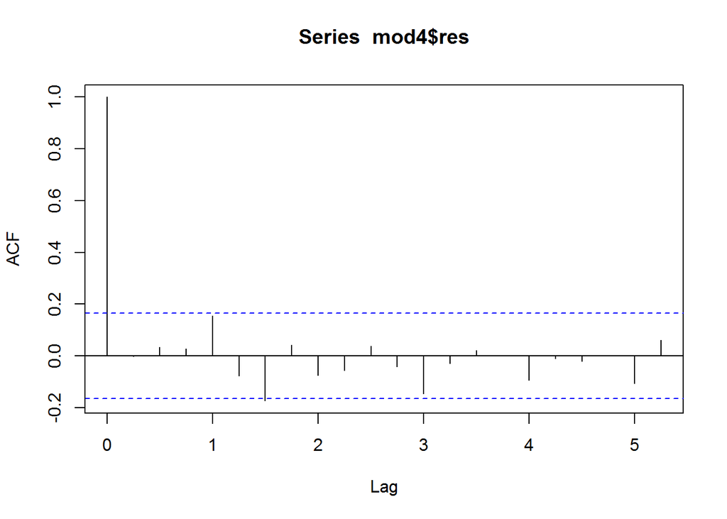

```r
#p-value > 0.05 => H0 priimame. mod3 liekanos yra baltasis triukšmas.

acf(mod4$res)  # Tikėtina, kad bus baltasis triukšmas.
```

```r
Box.test(mod4$res, fitdf=0, type="Lj")
```

```
##
##  Box-Ljung test
##
## data:  mod4$res
## X-squared = 7e-04, df = 1, p-value = 0.9794
```

```r
#p-value > 0.05 => H0 priimame. mod4 liekanos yra baltasis triukšmas.
```

Gavome, kad ne visų modelių liekonos yra baltasis triukšmas.

**(b)** Išskiriame duomenis į `trainSet` ir `testSet`:

```r
trainSet<-window(ser, end=c(1987,4))
testSet<-window(ser, start=c(1988,1))
```

**(c)** Visus keturis modelius pritaikome `trainSet` duomenim:

```r
mod11<-ets(trainSet, model='ANA')
mod22<-holt(trainSet, h=20)
mod33<-arima(trainSet, order = c(1,1,0),seasonal = list(order=c(2,0,1),period=4))
mod44<-arima(trainSet, order = c(2,1,1),seasonal = list(order=c(1,0,1),period=4))
```

**(d)** Išbrėžkite visų keturių modelių prognozes (su pasikliautinais intervalais). Ir ant viršaus išbrėžkite faktines reikšmes iš testSet duomenų. Kuri prognozė atrodo geriausia?

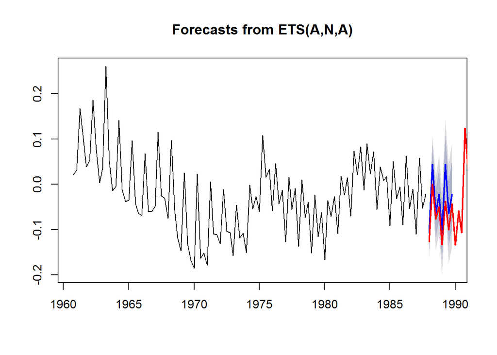

```r
# Nežinau kodėl neišbrėžia gražiai grafikų, bet moku tik taip.
plot(forecast(mod11))
lines(testSet, col=2, lwd=2)
```

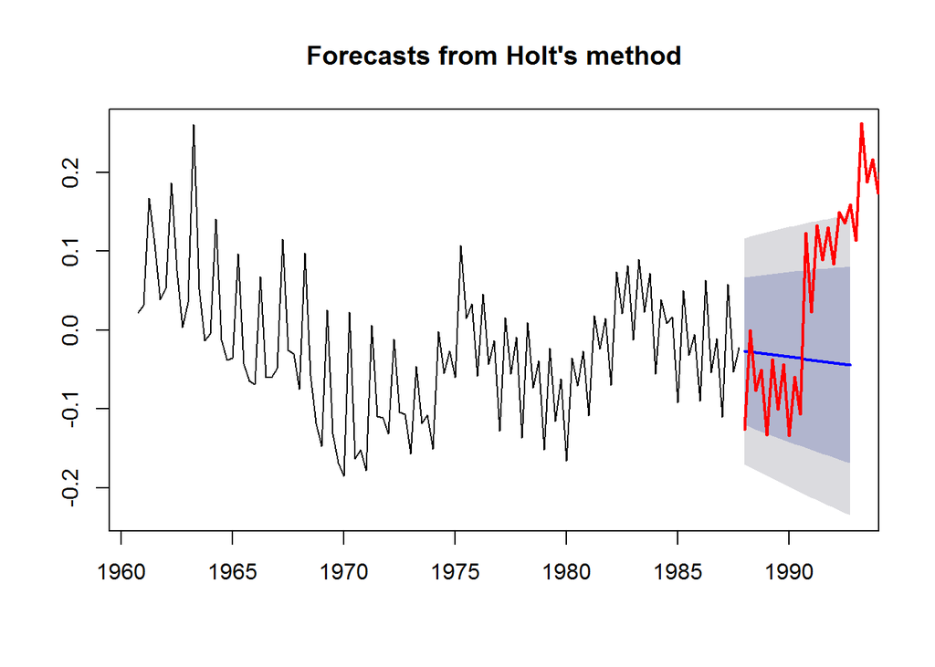

```r
plot(forecast(mod22))
lines(testSet, col=2, lwd=2)
```

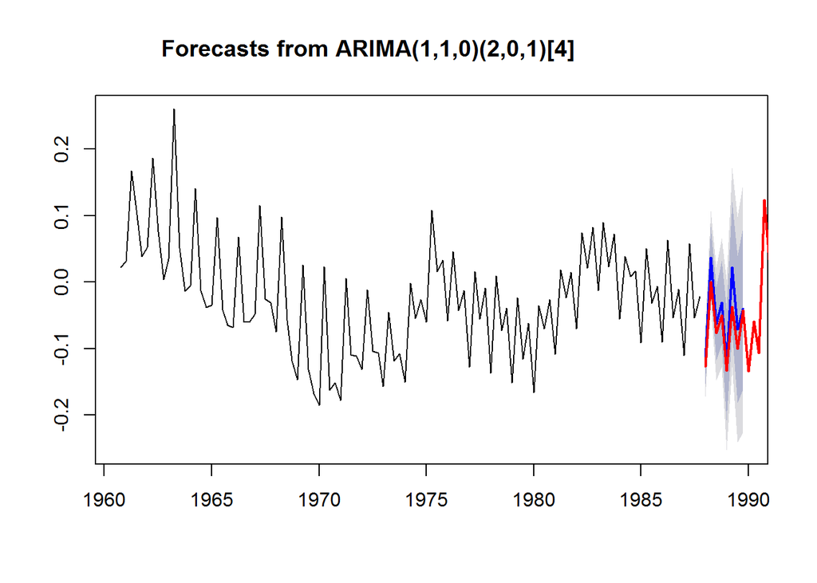

```r
plot(forecast(mod33))
lines(testSet, col=2, lwd=2)
```

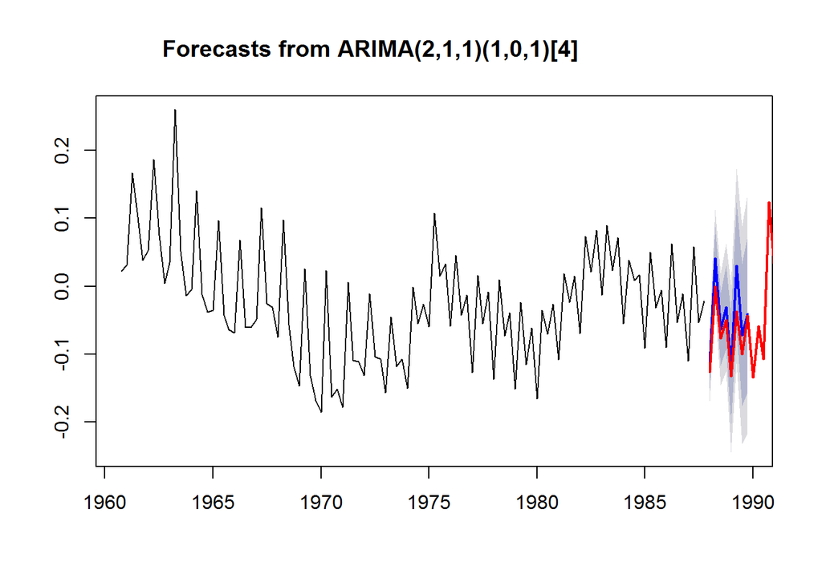

```r
plot(forecast(mod44))
lines(testSet, col=2, lwd=2)
```

Panašu, kad geriausia prognozė yra mod33.

**(e)** Tikriname modelių `accuracy`:

```r
library(knitr)

lent<-rbind (
  accuracy(forecast(mod11), ser)[,2],
  accuracy(forecast(mod22), ser)[,2],
  accuracy(forecast(mod33), ser)[,2],
  accuracy(forecast(mod44), ser)[,2]
)
rownames(lent) <- c("mod11 prognozė", "mod22 prognozė", "mod33 prognozė", "mod44 prognozė")
kable(lent, digits=5)
```

[output not shown]

```r
modMain<-mod3
```